# **Preprocessing**

### CSV Setup

Data exploration cannot begin without first importing the `.csv` file of the dataset into Python.

```python
import pandas as pd
import csv
import matplotlib.pyplot as plt
import numpy as np

dataset_filepath = 'https://drive.google.com/file/d/1rgziFHkmWJWCzrUKVsSkqKaav4nNPCu_/view?usp=sharing'
#dataset_filepath = 'https://drive.google.com/file/d/1OdwzSswOhIWm3MJ7euZQ-TvNYlm7feCS/view?usp=sharing'

dataset_filepath = 'https://drive.google.com/uc?id=' + dataset_filepath.split('/')[-2]
raw_dataset = pd.read_csv(dataset_filepath)

print(raw_dataset.columns)
print("Number of columns:", raw_dataset.shape[1])
print("Number of rows:", raw_dataset.shape[0])
raw_dataset.head(3)
```

```
Index(['ID', 'Timestamp', 'Tweet URL', 'Group', 'Collector', 'Category',
       'Topic', 'Keywords', 'Account handle', 'Account name', 'Account bio',
       'Account type', 'Joined', 'Following', 'Followers', 'Location', 'Tweet',
       'Tweet Translated', 'Tweet Type', 'Date posted', 'Screenshot',
       'Content type', 'Likes', 'Replies', 'Retweets', 'Quote Tweets', 'Views',
       'Rating', 'Reasoning', 'Remarks', 'Add columns here',
       'Add columns here.1', 'Add columns here.2', 'Reviewer', 'Review'],
      dtype='object')
Number of columns: 35
Number of rows: 982
```

|  | ID | Timestamp | Tweet URL | Group | Collector | Category | Topic | Keywords | Account handle | Account name | ... | Quote Tweets | Views | Rating | Reasoning | Remarks | Add columns here | Add columns here.1 | Add columns here.2 | Reviewer | Review |
| --- | --- | --- | --- | --- | --- | --- | --- | --- | --- | --- | --- | --- | --- | --- | --- | --- | --- | --- | --- | --- | --- |
| 0 | 48--1 | 29/03/23 01:43:00 | https://twitter.com/kuyamanzano/status/1219008... | 48.0 | Achapero, John | GOVT | War on drugs related mis/disinformation | #du30, drug | @kuyamanzano | Kuya Manzano | ... | 0.0 | NaN | NaN | The College Editors Guild of the Philippines s... | NaN | NaN | NaN | NaN | NaN | NaN |
| 1 | 48-2 | 29/03/23 01:43:00 | https://twitter.com/kuyamanzano/status/1218876... | 48.0 | Achapero, John | GOVT | War on drugs related mis/disinformation | #du30, drug | @kuyamanzano | Kuya Manzano | ... | 0.0 | NaN | NaN | The College Editors Guild of the Philippines s... | NaN | NaN | NaN | NaN | NaN | NaN |
| 2 | 48-3 | 29/03/23 01:43:00 | https://twitter.com/pinoy1954/status/118614342... | 48.0 | Achapero, John | GOVT | War on drugs related mis/disinformation | #du30, drug | @pinoy1954 | Roberto Gosim | ... | 0.0 | NaN | NaN | Rappler has already covered this information i... | URL leads to a Facebook post by himself with t... | NaN | NaN | NaN | NaN | NaN |

3 rows × 35 columns

982 rows? We don't have that much data. Filter out all any empty rows:

```python
raw_dataset = raw_dataset.loc[~raw_dataset['Tweet'].isnull()]
print("Number of rows:", raw_dataset.shape[0], "\n")
```

```
Number of rows: 155
```

Data also has a bunch of empty and unnecessary columns (i.e., group and collector) which can be removed:

```python
empty_columns = raw_dataset.columns[raw_dataset.isnull().sum() == raw_dataset.shape[0]].tolist() #filter all the columns which have all cells as null
unnecessary_columns = ['Group', 'Collector']
dataset = raw_dataset.drop(empty_columns + unnecessary_columns, axis = 1) #remove the columns filtered above
print("Number of columns: ", dataset.shape[1])
print("Number of rows:", dataset.shape[0])
dataset.head(3)
```

```
Number of columns:  25
Number of rows: 155
```

|  | ID | Timestamp | Tweet URL | Category | Topic | Keywords | Account handle | Account name | Account bio | Account type | ... | Tweet Translated | Tweet Type | Date posted | Content type | Likes | Replies | Retweets | Quote Tweets | Reasoning | Remarks |
| --- | --- | --- | --- | --- | --- | --- | --- | --- | --- | --- | --- | --- | --- | --- | --- | --- | --- | --- | --- | --- | --- |
| 0 | 48--1 | 29/03/23 01:43:00 | https://twitter.com/kuyamanzano/status/1219008... | GOVT | War on drugs related mis/disinformation | #du30, drug | @kuyamanzano | Kuya Manzano | Actor at #HesIntoHer - Singer - Director - Pro... | Identified | ... | NaN | Text | 20/01/20 05:25 | Rational | 5.0 | 0.0 | 0.0 | 0.0 | The College Editors Guild of the Philippines s... | NaN |
| 1 | 48-2 | 29/03/23 01:43:00 | https://twitter.com/kuyamanzano/status/1218876... | GOVT | War on drugs related mis/disinformation | #du30, drug | @kuyamanzano | Kuya Manzano | Actor at #HesIntoHer - Singer - Director - Pro... | Identified | ... | NaN | Text | 19/01/20 08:44 | Rational | 3.0 | 0.0 | 0.0 | 0.0 | The College Editors Guild of the Philippines s... | NaN |
| 2 | 48-3 | 29/03/23 01:43:00 | https://twitter.com/pinoy1954/status/118614342... | GOVT | War on drugs related mis/disinformation | #du30, drug | @pinoy1954 | Roberto Gosim | Realtor with American Financial Group based in... | Identified | ... | NaN | Text, URL | 21/10/19 23:53 | Rational | 0.0 | 0.0 | 0.0 | 0.0 | Rappler has already covered this information i... | URL leads to a Facebook post by himself with t... |

3 rows × 25 columns

Quickly check for duplicates:

```python
len(dataset['Tweet'].unique())
```

```
155
```

### Anonymization

The dataset's features can be categorized into the following

Qualitative data: `ID`, `Tweet URL*`, `Group`, `Collector`, `Category`, `Topic`, `Keywords`, `Account handle*`, `Account name*`, `Account bio*`, `Account type`, `Location`, `Tweet*`, `Tweet Translated`, `Tweet Type`, `Content type`, `Reasoning`, `Remarks`

Quantitative data: `Timestamp`, `Joined`, `Following`, `Followers`, `Date posted`, `Likes`, `Replies`, `Retweets`, `Quote Tweets`

Note that the features above marked with `*` are *identifiable features.* In order to **anonymize the data,** we have to remove these features.

```python
dataset['Account code'] = pd.factorize(raw_dataset['Account handle'])[0]

identifiable_columns = ['Tweet URL', 'Account handle', 'Account name', 'Account bio', 'Tweet']
dataset.drop(columns=identifiable_columns, inplace=True)
dataset.head(3)
```

|  | ID | Timestamp | Category | Topic | Keywords | Account type | Joined | Following | Followers | Location | ... | Tweet Type | Date posted | Content type | Likes | Replies | Retweets | Quote Tweets | Reasoning | Remarks | Account code |
| --- | --- | --- | --- | --- | --- | --- | --- | --- | --- | --- | --- | --- | --- | --- | --- | --- | --- | --- | --- | --- | --- |
| 0 | 48--1 | 29/03/23 01:43:00 | GOVT | War on drugs related mis/disinformation | #du30, drug | Identified | 03/11 | 22900.0 | 25192.0 | Philippines | ... | Text | 20/01/20 05:25 | Rational | 5.0 | 0.0 | 0.0 | 0.0 | The College Editors Guild of the Philippines s... | NaN | 0 |
| 1 | 48-2 | 29/03/23 01:43:00 | GOVT | War on drugs related mis/disinformation | #du30, drug | Identified | 03/11 | 22900.0 | 25192.0 | Philippines | ... | Text | 19/01/20 08:44 | Rational | 3.0 | 0.0 | 0.0 | 0.0 | The College Editors Guild of the Philippines s... | NaN | 0 |
| 2 | 48-3 | 29/03/23 01:43:00 | GOVT | War on drugs related mis/disinformation | #du30, drug | Identified | 02/09 | 4833.0 | 2288.0 | Signal Hill, CA | ... | Text, URL | 21/10/19 23:53 | Rational | 0.0 | 0.0 | 0.0 | 0.0 | Rappler has already covered this information i... | URL leads to a Facebook post by himself with t... | 1 |

3 rows × 21 columns

### Data verification

Verify that each row contains its necessary features:

```python
print("Empty URLs:", raw_dataset['Tweet URL'].isnull().sum())
print("Empty Twitter Handles:", raw_dataset['Account handle'].isnull().sum())
print("Empty Tweets:", raw_dataset['Tweet'].isnull().sum())
print("Empty Dates Posted:", raw_dataset['Date posted'].isnull().sum())
```

```
Empty URLs: 0
Empty Twitter Handles: 0
Empty Tweets: 0
Empty Dates Posted: 0
```

The most relevant column to our group is date posted, so get a quick overview of that column:

```python
pd.to_datetime(dataset['Date posted'], dayfirst=True).describe(datetime_is_numeric=True)
```

```
count                              155
mean     2018-09-29 19:06:46.451613184
min                2016-01-10 07:39:00
25%                2017-03-18 19:15:30
50%                2018-08-16 07:07:00
75%                2019-09-27 22:51:00
max                2022-10-18 08:23:00
Name: Date posted, dtype: object
```

There are no Tweets that lie outside of the instructed range (2016 to 2022).

Try making some code for quick-checking formats:

```python
counts = 0
for date in dataset['Date posted']: #check formats of date
  is_wrong = False
  date_posted = date.strip().split()
  date_format = date_posted[0].split('/')
  time = date_posted[1].split(':')
  if (len(date_format) != 3 or len(time) != 2 or  #if formats are right they should have the right length
    int(date_format[0]) > 31 or #low level check of day
    int(date_format[1]) > 12 or #check month
    int(date_format[2]) > 22 or #check year upper bound
    int(date_format[2]) < 16 or #check year lower bound
    int(time[0]) > 24 or #check hour
    int(time[1]) > 59): #check minutes
      print(date)
      is_wrong = True

  if is_wrong: counts += 1

print("Number of wrong formatted cells under Date posted column:", counts)
```

```
Number of wrong formatted cells under Date posted column: 0
```

Formatting of relevant columns looks correct.

# Visualization

### Overview graphs

Try low-hanging-fruit graphs:

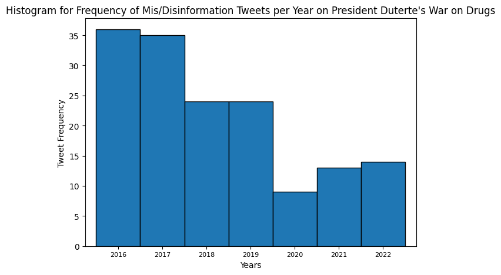

```python
dataset['Year'] = pd.to_datetime(dataset['Date posted'], dayfirst=True).dt.year
dataset['Year'].value_counts().sort_index().plot.bar(width=1, edgecolor='black') #using a bar graph for easier manipulation of graphics (like centering xticks)

plt.xlabel('Years')
plt.ylabel('Tweet Frequency')
plt.title('Histogram for Frequency of Mis/Disinformation Tweets per Year on President Duterte\'s War on Drugs')
plt.yticks(range(0, dataset['Year'].value_counts().max(), 5)) #make y-axis integers
plt.xticks(rotation=0, fontsize=8)
plt.tight_layout()
```

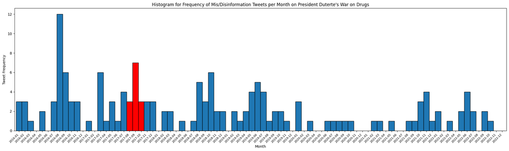

```python
dataset['Month'] = pd.to_datetime(dataset['Date posted'], dayfirst=True).dt.to_period('M')

index = pd.period_range(start='2016-01', end='2022-12', freq='M') #need to clarify index to ensure months with no tweets are included

plt.figure(figsize=(20, 6))
histo = dataset.groupby('Month')['ID'].count().astype(int).reindex(index).plot.bar(x='Month', y='Frequency', width=1, edgecolor='black') #using a bar graph for easier manipulation of graphics (like centering xticks)

# Recolors target month
# target_month = '2017-09'
# target_index = index.get_loc(pd.Period(target_month, freq='M'))
# histo.patches[target_index].set_facecolor('red')

# Recolor the target months
target_months = ['2017-08', '2017-09', '2017-10']
target_indices = [index.get_loc(pd.Period(month, freq='M')) for month in target_months]
for index in target_indices:
    histo.patches[index].set_facecolor('red')

plt.xlabel('Month')
plt.ylabel('Tweet Frequency')
plt.title('Histogram for Frequency of Mis/Disinformation Tweets per Month on President Duterte\'s War on Drugs')
plt.xticks(rotation=45, ha='right', fontsize=8)
plt.tight_layout()
```

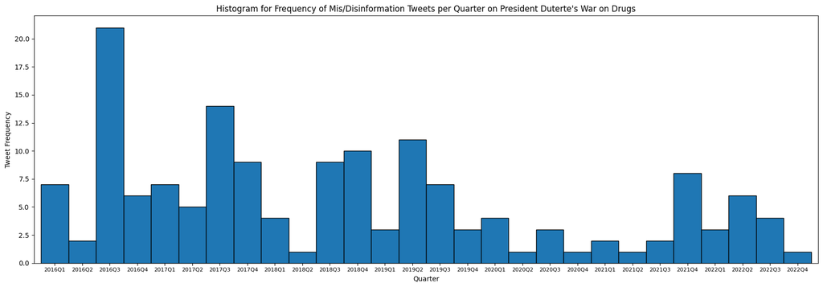

```python
dataset['Quarter'] = pd.to_datetime(dataset['Date posted'], dayfirst=True).dt.to_period('Q')

index = pd.period_range(start='2016-01', end='2022-12', freq='Q')

plt.figure(figsize=(17, 6))
histo = dataset.groupby('Quarter')['ID'].count().astype(int).reindex(index).plot.bar(width=1, edgecolor='black') #using a bar graph for easier manipulation of graphics (like centering xticks)

plt.xlabel('Quarter')
plt.ylabel('Tweet Frequency')
plt.title('Histogram for Frequency of Mis/Disinformation Tweets per Quarter on President Duterte\'s War on Drugs')
plt.xticks(rotation=0, fontsize=8)
plt.tight_layout()
```

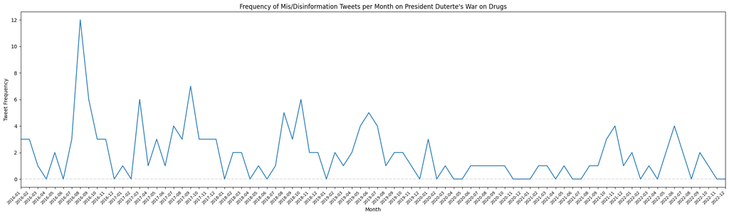

```python
dataset['Month'] = pd.to_datetime(dataset['Date posted'], dayfirst=True).dt.to_period('M')

index = pd.period_range(start='2016-01', end='2022-12', freq='M')

plt.figure(figsize=(20, 6))

line = dataset.groupby('Month')['ID'].count().astype(int).reindex(index)
line = line.fillna(0) # sets other months into "0" to prevent the line graph from cutting out
line.plot.line(x='Month', y='Frequency')

# Adds line for target month
# plt.axvline(x=pd.Period('2017-09', freq='M').to_timestamp(), color='red', linestyle='--')

plt.axhline(y=0, color='gray', linestyle='--', alpha=0.25)

plt.xlabel('Month')
plt.ylabel('Tweet Frequency')
plt.title('Frequency of Mis/Disinformation Tweets per Month on President Duterte\'s War on Drugs')
plt.xticks(rotation=45, ha='right', fontsize=8, ticks=line.index.to_timestamp(), labels=line.index.strftime('%Y-%m'))
#plt.xticks(rotation=45, ha='right', fontsize=8)
plt.tight_layout()
```

### Interpolated graphs

The following graphs have interpolated values:

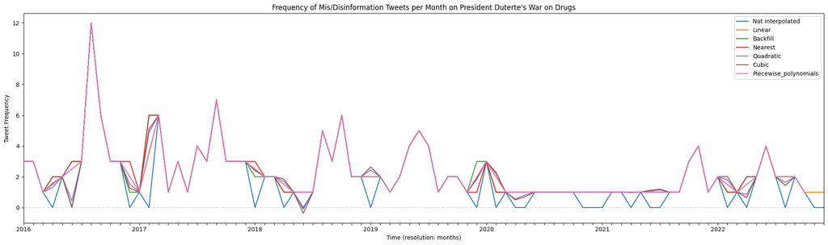

```python
dataset['Month'] = pd.to_datetime(dataset['Date posted'], dayfirst=True).dt.to_period('M').dt.to_timestamp() #get year and month

index = pd.period_range(start='2016-01', end='2022-12', freq='M').to_timestamp() #get range of years
#debug code for checking the column contents
#with pd.option_context('display.max_rows', None, 'display.max_columns', None):
#    print(dataset['Month'].value_counts().reindex(index).astype(pd.Int8Dtype()))

plt.figure(figsize=(20, 6))

line = dataset['Month'].value_counts().reindex(index)#get the count of tweets per month, reindex it to include missing months, fill missing months with 0s, then convert count to integer to revert NaN promotion

#check a few interpolation methods
line.fillna(0).plot.line(label='Not interpolated')
line.interpolate().plot.line(label='Linear')
line.interpolate(method='bfill').plot.line(label='Backfill')
line.interpolate(method='nearest').plot.line(label='Nearest')
line.interpolate(method='quadratic').plot.line(label='Quadratic')
line.interpolate(method='cubic').plot.line(label='Cubic')
line.interpolate(method='piecewise_polynomial').plot.line(label='Piecewise_polynomials')

# Adds line for target month
# plt.axvline(x=pd.Period('2017-09', freq='M').to_timestamp(), color='red', linestyle='--')

plt.axhline(y=0, color='gray', linestyle='--', alpha=0.25)

plt.legend(loc="upper right")
plt.xlabel('Time (resolution: months)')
plt.ylabel('Tweet Frequency')
plt.xticks(index)
plt.title('Frequency of Mis/Disinformation Tweets per Month on President Duterte\'s War on Drugs')
plt.tight_layout()
```

Interpolating by year doesn't matter, because each year has a value and `.interpolate()` only fills `NaN` values.

Any method of interpolation which creates a smooth curve (quadratic, cubic) creates negative values in order to preserve peaks in the values. The positive interpolations have pros and cons as follows:

1. **Linear:** Simplistic and unrealistic; it is difficult to believe that a straight line represents values with any accuracy
2. **Nearest:** As data values are few and far between (such as many gaps between the points) getting the nearest point to use as a value of interpolation causes repetitive counts.
3. **Backfill:** Similar downsides to Nearest interpolation
4. **Piecewise polynomials:** does not interpolate last and starting values due to constraints of interpolation (requires two points)

From the above, perhaps piecewise polynomials are most promising:

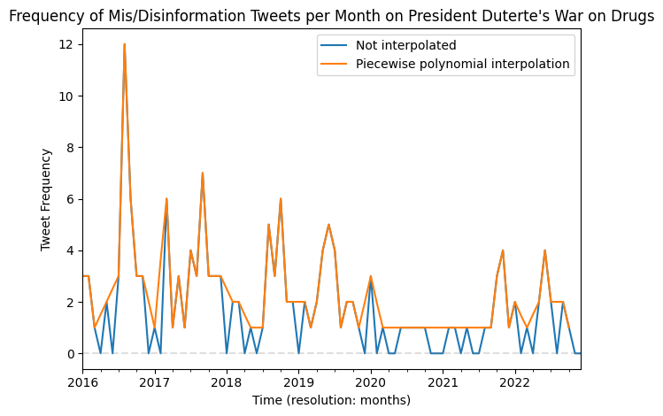

```python
line.fillna(0).plot.line(label='Not interpolated')
line.interpolate(method='piecewise_polynomial').plot.line(label='Piecewise polynomial interpolation')

plt.axhline(y=0, color='gray', linestyle='--', alpha=0.25)

plt.legend(loc="upper right")
plt.xlabel('Time (resolution: months)')
plt.ylabel('Tweet Frequency')
plt.title('Frequency of Mis/Disinformation Tweets per Month on President Duterte\'s War on Drugs')
plt.tight_layout()
```

Try the same but for per-quarter groupings:

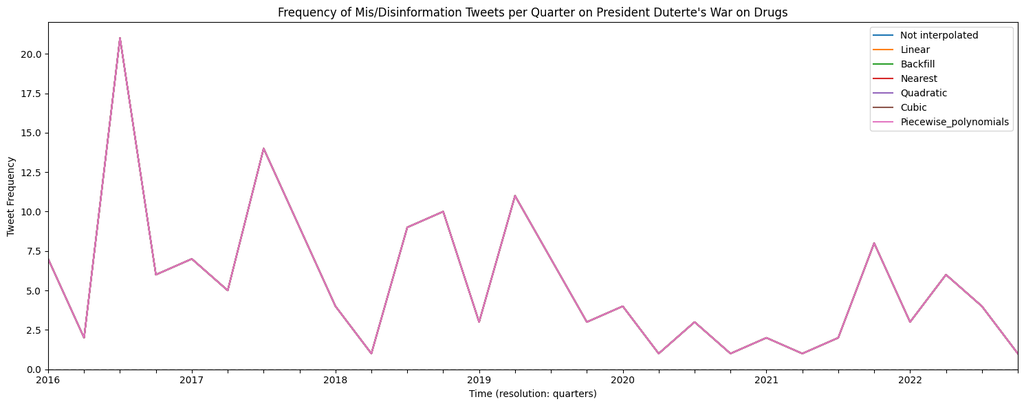

```python
dataset['Quarter'] = pd.to_datetime(dataset['Date posted'], dayfirst=True).dt.to_period('Q').dt.to_timestamp() #get year and month

index = pd.period_range(start='2016-01', end='2022-12', freq='Q').to_timestamp() #get range of years
#debug code for checking the column contents
#with pd.option_context('display.max_rows', None, 'display.max_columns', None):
#    print(dataset['Month'].value_counts().reindex(index).astype(pd.Int8Dtype()))

plt.figure(figsize=(15, 6))

line = dataset['Quarter'].value_counts().reindex(index)#get the count of tweets per month, reindex it to include missing months, fill missing months with 0s, then convert count to integer to revert NaN promotion

#check a few interpolation methods
line.fillna(0).plot.line(label='Not interpolated')
line.interpolate().plot.line(label='Linear')
line.interpolate(method='bfill').plot.line(label='Backfill')
line.interpolate(method='nearest').plot.line(label='Nearest')
line.interpolate(method='quadratic').plot.line(label='Quadratic')
line.interpolate(method='cubic').plot.line(label='Cubic')
line.interpolate(method='piecewise_polynomial').plot.line(label='Piecewise_polynomials')

# Adds line for target month
# plt.axvline(x=pd.Period('2017-09', freq='M').to_timestamp(), color='red', linestyle='--')
plt.axhline(y=0, color='gray', linestyle='--', alpha=0.25)

plt.legend(loc="upper right")
plt.xlabel('Time (resolution: quarters)')
plt.ylabel('Tweet Frequency')
plt.xticks(index)
plt.title('Frequency of Mis/Disinformation Tweets per Quarter on President Duterte\'s War on Drugs')
plt.tight_layout()
```

The problems of curved interpolation seem less apparent here. This could indicate that more input tweets are necessary.

We are unsure where interpolation may be useful in the study as of yet, so the above graphs serve more as a test than as an informative graph.

### Binned graphs

One idea is to bin the graphs by event. Because the event relevant to the study is Kian delos Santos's death, we can separate the times around the event (arbitrarily, from August 2017 to October 2017). There are two possible ways to bin the remaining tweets: either all in their own bin, or two separate bins (one before the event and one after).

Starting with the first (one bin for the event and one bin for otherwise):

```
Total tweets: 155
```

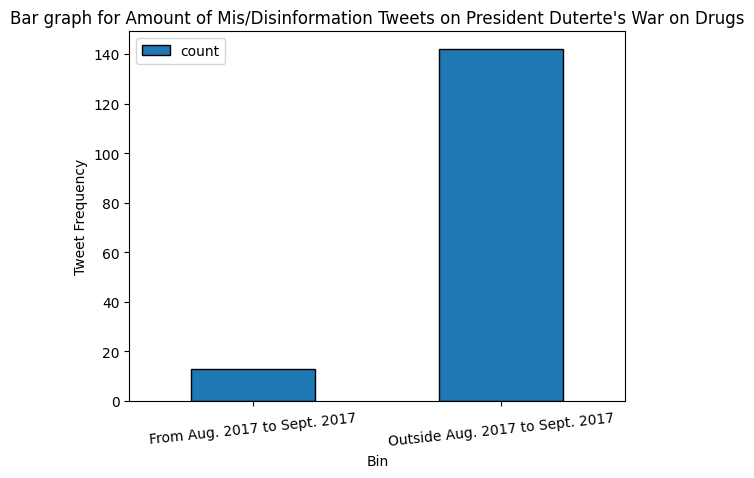

```python
event_bin = dataset[(dataset['Month'] <= "2017-10") & (dataset['Month'] >= "2017-08")].shape[0] #number of tweets found within 08-2017 and 10-2018
non_event_bin = dataset[(dataset['Month'] > "2017-10") | (dataset['Month'] < "2017-08")].shape[0]

d = {'Bin': ['From Aug. 2017 to Sept. 2017', 'Outside Aug. 2017 to Sept. 2017'], 'count': [event_bin, non_event_bin]}
small_dataset = pd.DataFrame(data=d).set_index('Bin')
small_dataset.plot.bar(edgecolor = 'black')

plt.xlabel('Bin')
plt.ylabel('Tweet Frequency')
plt.title('Bar graph for Amount of Mis/Disinformation Tweets on President Duterte\'s War on Drugs')

plt.xticks(rotation=6)

print("Total tweets:",event_bin + non_event_bin)
```

Now the second (three bins: before, during, after):

```
Total tweets: 155
```

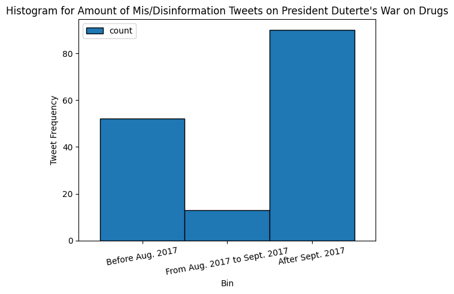

```python
event_bin = dataset[(dataset['Month'] <= "2017-10") & (dataset['Month'] >= "2017-08")].shape[0] #number of tweets found within 08-2017 and 10-2017
after_bin = dataset[(dataset['Month'] > "2017-10")].shape[0]
before_bin = dataset[(dataset['Month'] < "2017-08")].shape[0]

d = {'Bin': ['Before Aug. 2017', 'From Aug. 2017 to Sept. 2017', 'After Sept. 2017'], 'count': [before_bin, event_bin, after_bin]}
small_dataset = pd.DataFrame(data=d).set_index('Bin')
small_dataset.plot.bar(width=1, edgecolor = "black")

plt.xlabel('Bin')
plt.ylabel('Tweet Frequency')
plt.title('Histogram for Amount of Mis/Disinformation Tweets on President Duterte\'s War on Drugs')

plt.xticks(rotation=10)

print("Total tweets:", event_bin + after_bin + before_bin)
```

# **Further exploration**

### Finding the number of unique accounts

Thanks to the new "Account code" column, we can easily count the number of unique accounts:

```python
print("Number of unique accounts:", dataset['Account code'].nunique())
```

```
Number of unique accounts: 138
```

### Finding accounts with multiple tweets

Through pandas' indexing system, accounts with multiple tweets are easily found.

```python
print("Displaying account codes which appear more than once:")
account_codes = dataset['Account code'].value_counts().index[dataset['Account code'].value_counts() > 1].tolist()
account_counts = dataset['Account code'].value_counts()[dataset['Account code'].value_counts() > 1].tolist()
for code, count in zip(account_codes, account_counts):
  print("Account code:", code, "| Count:", count)
```

```
Displaying account codes which appear more than once:
Account code: 0 | Count: 5
Account code: 5 | Count: 3
Account code: 117 | Count: 3
Account code: 18 | Count: 2
Account code: 68 | Count: 2
Account code: 57 | Count: 2
Account code: 51 | Count: 2
Account code: 35 | Count: 2
Account code: 109 | Count: 2
Account code: 24 | Count: 2
Account code: 107 | Count: 2
Account code: 2 | Count: 2
```

### Average number of tweets per account

A fun statistic to find may be the average number of tweets per account:

```python
print("Mean number of tweets per account:", dataset['Account code'].value_counts().mean())
print("Median number of tweets per account:", dataset['Account code'].value_counts().median())
```

```
Mean number of tweets per account: 1.1231884057971016
Median number of tweets per account: 1.0
```

It appears that the mean amount of tweets an account has in the dataset is approximately 1.12, though the majority of the accounts in the dataset are unique. Note that 12 accounts appear in the dataset more than once.